# COR_resubmission_Analysis

CPR

March 6, 2018

**This file will repeat the analysis, but include the correct data for reproductive status**. * This will change all the tables and figures. * This *might* end up changing the sample size! I will not include menarcheal age, though we discussed this as an option. Might be good to include a side note in the paper that menarcheal age does not predict parity, so no support for that dimension of life history pace.

# 1 Loading the data and packages.

## 1.1 Load DNAmAge data:

- I cannot use *age adjusted* values for DNAmAge, because I have used unrounded Age values that were accurate for 2005, but not for the 2005 blood draw.
- I can calculate a new value called DNAmAgeAdjAge.blood.
- It is not necessary for most of my analyses, which employ DNAmAge, not calculated using ‘age’ (doesn’t use residuals). There I am including the icage05_blood measure separately.
- It is necessary for my final measures predicting parity over subsequent years, because there I need an age corrected value as a predictor…
- See more in the Parity test section below.

## 1.2 Load Dan’s data here. Note that I’m using the most recent file sent after finding missing data. (“~/Academic/PhD/Projects/eAge/eAge_effects/Pre_Pub_analyses/remissingdata/**2017-12-01 file for Calen.dta**”).

```r
dan.new <- read_dta("~/Academic/PhD/Projects/eAge/eAge_effects/Pre_Pub_analyses/remissingdata/2017-12-01 file for Calen.dta")

dan.new$uncchdid <-as.character(dan.new$uncchdid)
```

## 1.3 Merge Dan’s and the DNAmAge datasets

```r
# Merge
raw.dan2 <-dplyr::full_join(dan.new, eage.unround[eage.unround$Female == "1",], by = "uncchdid")
```

## 1.4 Load menarcheal age and see that we have data for all individuals.

```r
menar <-read_dta("/Users/CPR/Academic/PhD/Projects/eAge/eAge_effects/Pre_Pub_analyses/Resub/menagerepro.dta")

menar$uncchdid <-as.character(menar$uncchdid)
menar$reprostat <-as.factor(menar$reprostat)

raw.dan <-left_join(raw.dan2, menar, by = "uncchdid");
levels(raw.dan$reprostat)
```

```
## [1] "0"   "1"   "2"   "3"   "NaN"
```

Individuals with NaN, presumably NA. Remove.

```r
# Just to look at the NaN value for reprostat for the women I'm interested in.
raw.dan %>%
  select(uncchdid, currently_pregnant, reprostat, DNAmAge, numbpreg) %>%
  filter(reprostat == "NaN")
```

```
## # A tibble: 9 x 5
##   uncchdid currently_pregnant reprostat  DNAmAge numbpreg
##      <chr>              <dbl>    <fctr>    <dbl>    <dbl>
## 1    22980                  0       NaN 29.72974      NaN
## 2    22569                  0       NaN       NA        0
## 3    22595                  0       NaN       NA      NaN
## 4    22046                  0       NaN       NA        0
## 5    23131                  0       NaN       NA        0
## 6    20666                  0       NaN       NA      NaN
## 7    23320                  0       NaN       NA        0
## 8    23311                  0       NaN       NA        0
## 9    23323                  0       NaN       NA        3
```

Change that individual (23323) to correct reprostat.

```r
raw.dan[which(raw.dan$reprostat == "NaN" & raw.dan$numbpreg != "NaN" & raw.dan$DNAmAge != "NaN"), "reprostat"] <- 0
```

### 1.4.1 Check all my values for reprostat and pregnancy and then recreate a new pregnancy variable.

```r
# Remove NaN and drop that level.
raw.dan <-raw.dan %>%
filter(reprostat != "NaN") %>%
droplevels()
```

Check values for preg and not by reprostat

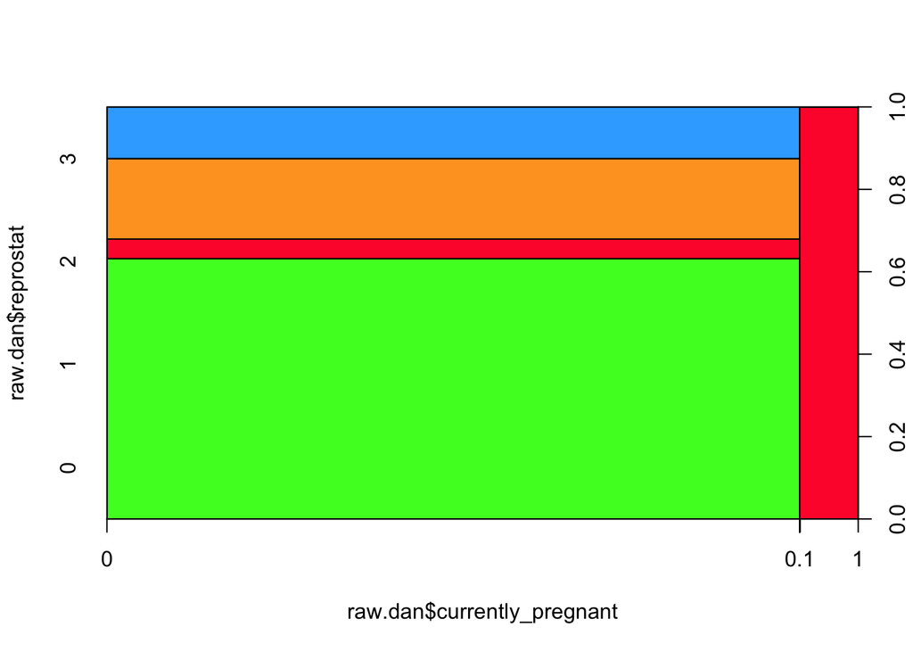

```r
plot(raw.dan$reprostat~raw.dan$currently_pregnant, col = c("#45FF28", "#FF2838","#FFA228", "#36ACFF"))
```

```r
raw.dan$currently_pregnant2 <-ifelse(raw.dan$reprostat == 1,
       "pregnant",
       "not pregnant")
```

Check consistency between currently pregnant (old) and (new) (categorical)

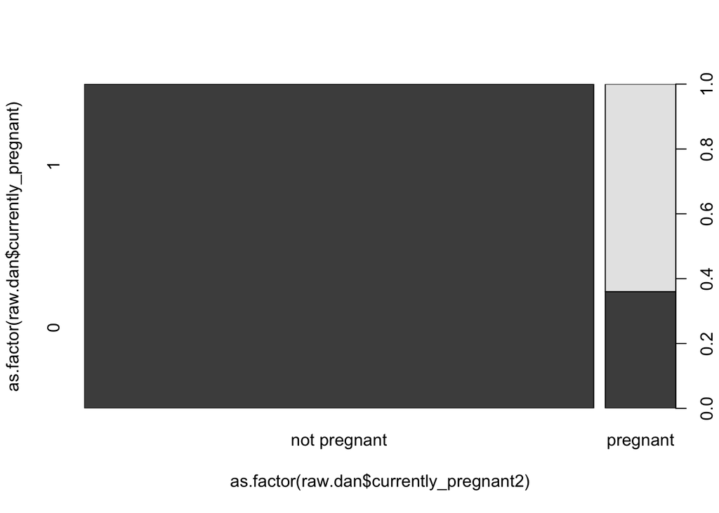

```r
plot(as.factor(raw.dan$currently_pregnant)~as.factor(raw.dan$currently_pregnant2))
```

> The above plot shows that ALL women listed as not pregnant from the menar file (reprostat) were not pregnant in the original file. It also shows that some women who were later found to be pregnant (reprostat) were listed as NOT pregnant in the original file. This makes sense.

## 1.5 Output table of DNAm individuals only.

```r
raw.dan.dnam <-raw.dan %>%
  select(DNAmAge, icage05_blood, numbpreg, starts_with("icpc"), -contains('fat') , SES3, urbanicity, currently_pregnant, currently_pregnant2) %>%
  mutate(AgeDiff = DNAmAge - icage05_blood) %>%
  na.omit()

raw.dan.dnam$currently_pregnant2 <-as.factor(raw.dan.dnam$currently_pregnant2)

stargazer::stargazer(data.frame(raw.dan.dnam), type = "html", out = "dnam_summary.html")
```

| Statistic | N | Mean | St. Dev. | Min | Max |
| --- | --- | --- | --- | --- | --- |
| DNAmAge | 397 | 25.612 | 3.183 | 13.889 | 34.900 |
| icage05_blood | 397 | 21.667 | 0.346 | 20.841 | 22.474 |
| numbpreg | 397 | 0.804 | 0.986 | 0 | 5 |
| icpc1 | 397 | -0.0004 | 0.024 | -0.067 | 0.071 |
| icpc2 | 397 | 0.001 | 0.023 | -0.083 | 0.068 |
| icpc3 | 397 | 0.0002 | 0.024 | -0.064 | 0.087 |
| icpc4 | 397 | -0.002 | 0.024 | -0.107 | 0.052 |
| icpc5 | 397 | -0.001 | 0.026 | -0.073 | 0.071 |
| icpc6 | 397 | -0.0002 | 0.024 | -0.068 | 0.075 |
| icpc7 | 397 | 0.0001 | 0.023 | -0.062 | 0.071 |
| icpc8 | 397 | 0.0002 | 0.025 | -0.081 | 0.068 |
| icpc9 | 397 | 0.001 | 0.025 | -0.077 | 0.075 |
| icpc10 | 397 | 0.001 | 0.024 | -0.073 | 0.066 |
| SES3 | 397 | -0.193 | 1.409 | -3.268 | 4.293 |
| urbanicity | 397 | 35.611 | 12.796 | 8.286 | 52.833 |
| currently_pregnant | 397 | 0.116 | 0.320 | 0 | 1 |
| AgeDiff | 397 | 3.945 | 3.182 | -7.462 | 13.941 |

## 1.6 Make a ‘full’ dataset, that includes all variables of interest

```r
raw.dan.tl <-raw.dan %>%
  select(telomereICwell, icage05_blood, numbpreg, starts_with("icpc"), -contains('fat') , SES3, urbanicity, currently_pregnant2, momeducation) %>%
  na.omit()

dim(raw.dan.tl)
```

[1] 821 17

```r
raw.dan.tl$currently_pregnant2 <-as.factor(raw.dan.tl$currently_pregnant2)

raw.dan.tl %>%
select(icage05_blood, numbpreg, currently_pregnant2, momeducation) %>%
  as.data.frame() %>%
  stargazer(nobs = T, mean.sd = T, min.max = T, type = 'html', out = "tl_summary.html")
```

| Statistic | N | Mean | St. Dev. | Min | Max |
| --- | --- | --- | --- | --- | --- |
| icage05_blood | 821 | 21.689 | 0.357 | 20.825 | 22.526 |
| numbpreg | 821 | 0.615 | 0.931 | 0 | 5 |
| momeducation | 821 | 7.764 | 3.754 | 0 | 19 |

```r
tb <-table(raw.dan.tl$numbpreg);tb
```

0 1 2 3 4 5 507 174 102 28 7 3

```r
tb[1]/sum(tb)
```

```
    0
```

0.6175396

```r
tb[2]/sum(tb)
```

```
    1
```

0.2119367

```r
tb[3]/sum(tb)
```

```
    2
```

0.1242387

```r
tb[4]/sum(tb)
```

```
     3
```

0.03410475

```r
tb[5]/sum(tb)
```

```
      4
```

0.008526188

# 2 DNA Models

## 2.1 DNAm Model 1, number of observations and VIF

```r
library(fmsb)
dnam1 <-lm(DNAmAge~icage05_blood + numbpreg, subset(raw.dan.dnam, ))
summary(dnam1)
```

```
##
## Call:
## lm(formula = DNAmAge ~ icage05_blood + numbpreg, data = subset(raw.dan.dnam,
##     ))
##
## Residuals:
##      Min       1Q   Median       3Q      Max
## -11.6407  -2.1332  -0.0179   2.1037   9.9235
##
## Coefficients:
##               Estimate Std. Error t value Pr(>|t|)
## (Intercept)    14.8178     9.9671   1.487   0.1379
## icage05_blood   0.4847     0.4602   1.053   0.2929
## numbpreg        0.3634     0.1616   2.248   0.0251 *
## ---
## Signif. codes:  0 '***' 0.001 '**' 0.01 '*' 0.05 '.' 0.1 ' ' 1
##
## Residual standard error: 3.165 on 394 degrees of freedom
## Multiple R-squared:  0.01608,    Adjusted R-squared:  0.01109
## F-statistic:  3.22 on 2 and 394 DF,  p-value: 0.04101
```

```r
raw.dan.dnamX <-raw.dan.dnam

raw.dan.dnamX$Cat[raw.dan.dnam$numbpreg == 0] <-0
raw.dan.dnamX$Cat[raw.dan.dnam$numbpreg == 1] <-1
raw.dan.dnamX$Cat[raw.dan.dnam$numbpreg == 2] <-2
raw.dan.dnamX$Cat[raw.dan.dnam$numbpreg >= 3] <-3


dnam1b <-lm(DNAmAge~icage05_blood + Cat, subset(raw.dan.dnamX, ))
summary(dnam1b)
```

```
##
## Call:
## lm(formula = DNAmAge ~ icage05_blood + Cat, data = subset(raw.dan.dnamX,
##     ))
##
## Residuals:
##      Min       1Q   Median       3Q      Max
## -11.6593  -2.1477  -0.0323   2.1261   9.9389
##
## Coefficients:
##               Estimate Std. Error t value Pr(>|t|)
## (Intercept)    15.1113     9.9641   1.517   0.1302
## icage05_blood   0.4700     0.4602   1.021   0.3078
## Cat             0.4031     0.1694   2.380   0.0178 *
## ---
## Signif. codes:  0 '***' 0.001 '**' 0.01 '*' 0.05 '.' 0.1 ' ' 1
##
## Residual standard error: 3.163 on 394 degrees of freedom
## Multiple R-squared:  0.01758,    Adjusted R-squared:  0.0126
## F-statistic: 3.526 on 2 and 394 DF,  p-value: 0.03035
```

```r
# All models using Cat were <0.05
```

The N is 397

Variance inflation for this model is 1.0163455

## 2.2 DNAm Model 2, number of observations and VIF

```r
dnam2 <-lm(DNAmAge~icage05_blood + numbpreg + SES3 + icpc1 + icpc2 + icpc3 + icpc4 + icpc5 + icpc6 + icpc7 + icpc8 + icpc9 + icpc10 + urbanicity, subset(raw.dan.dnam, ))
summary(dnam2);nobs(dnam2)
```

```
##
## Call:
## lm(formula = DNAmAge ~ icage05_blood + numbpreg + SES3 + icpc1 +
##     icpc2 + icpc3 + icpc4 + icpc5 + icpc6 + icpc7 + icpc8 + icpc9 +
##     icpc10 + urbanicity, data = subset(raw.dan.dnam, ))
##
## Residuals:
##      Min       1Q   Median       3Q      Max
## -10.6178  -2.0908  -0.0541   2.0535   9.2034
##
## Coefficients:
##                Estimate Std. Error t value Pr(>|t|)
## (Intercept)    10.31880   10.29929   1.002  0.31703
## icage05_blood   0.66661    0.46970   1.419  0.15665
## numbpreg        0.32596    0.16453   1.981  0.04829 *
## SES3           -0.18018    0.12364  -1.457  0.14584
## icpc1         -11.62254    6.69383  -1.736  0.08332 .
## icpc2           5.09829    6.86122   0.743  0.45790
## icpc3           8.51025    6.65681   1.278  0.20187
## icpc4          11.99052    6.56818   1.826  0.06870 .
## icpc5         -14.12340    6.17345  -2.288  0.02270 *
## icpc6          -4.00157    6.64538  -0.602  0.54743
## icpc7          18.51343    6.89619   2.685  0.00758 **
## icpc8           3.98724    6.40379   0.623  0.53389
## icpc9          -1.72991    6.45211  -0.268  0.78875
## icpc10         -2.70078    6.74678  -0.400  0.68915
## urbanicity      0.01547    0.01399   1.106  0.26937
## ---
## Signif. codes:  0 '***' 0.001 '**' 0.01 '*' 0.05 '.' 0.1 ' ' 1
##
## Residual standard error: 3.117 on 382 degrees of freedom
## Multiple R-squared:  0.07505,    Adjusted R-squared:  0.04116
## F-statistic: 2.214 on 14 and 382 DF,  p-value: 0.007011
```

```
## [1] 397
```

The N is 397

Variance inflation for this model is 1.0811445

## 2.3 DNAm Model 3, number of observations and VIF

```r
dnam3 <-lm(DNAmAge~icage05_blood + numbpreg + SES3 + icpc1 + icpc2 + icpc3 + icpc4 + icpc5 + icpc6 + icpc7 + icpc8 + icpc9 + icpc10  + urbanicity + currently_pregnant2, subset(raw.dan.dnam, ))
summary(dnam3)
```

```
##
## Call:
## lm(formula = DNAmAge ~ icage05_blood + numbpreg + SES3 + icpc1 +
##     icpc2 + icpc3 + icpc4 + icpc5 + icpc6 + icpc7 + icpc8 + icpc9 +
##     icpc10 + urbanicity + currently_pregnant2, data = subset(raw.dan.dnam,
##     ))
##
## Residuals:
##     Min      1Q  Median      3Q     Max
## -9.3422 -1.9477  0.0261  2.0756  8.9383
##
## Coefficients:
##                              Estimate Std. Error t value Pr(>|t|)
## (Intercept)                  10.61090   10.15886   1.044 0.296918
## icage05_blood                 0.65650    0.46328   1.417 0.157284
## numbpreg                      0.45852    0.16686   2.748 0.006283 **
## SES3                         -0.21443    0.12236  -1.752 0.080501 .
## icpc1                       -11.25032    6.60323  -1.704 0.089241 .
## icpc2                         4.79270    6.76802   0.708 0.479291
## icpc3                        10.07421    6.58177   1.531 0.126692
## icpc4                        10.44990    6.49409   1.609 0.108414
## icpc5                       -14.03262    6.08912  -2.305 0.021730 *
## icpc6                        -1.68258    6.58962  -0.255 0.798600
## icpc7                        21.21960    6.84793   3.099 0.002088 **
## icpc8                         3.92968    6.31627   0.622 0.534215
## icpc9                        -2.33201    6.36635  -0.366 0.714343
## icpc10                       -1.32878    6.66667  -0.199 0.842121
## urbanicity                    0.01725    0.01381   1.250 0.212159
## currently_pregnant2pregnant  -1.47153    0.43091  -3.415 0.000707 ***
## ---
## Signif. codes:  0 '***' 0.001 '**' 0.01 '*' 0.05 '.' 0.1 ' ' 1
##
## Residual standard error: 3.074 on 381 degrees of freedom
## Multiple R-squared:  0.1025, Adjusted R-squared:  0.06719
## F-statistic: 2.902 on 15 and 381 DF,  p-value: 0.0002323
```

```r
tidy.dnam3 <-broom::tidy(dnam3)

est <-tidy.dnam3[3,"estimate"]
err <-tidy.dnam3[3,"std.error"]

est
```

```
## [1] 0.458519
```

```r
est + err
```

```
## [1] 0.6253808
```

```r
est - err
```

```
## [1] 0.2916572
```

The N is 397

## 2.4 DNAm Model 4, number of observations and VIF

```r
dnam4 <-lm(DNAmAge~icage05_blood + numbpreg*SES3 + icpc1 + icpc2 + icpc3 + icpc4 + icpc5 + icpc6 + icpc7 + icpc8 + icpc9 + icpc10 + urbanicity + currently_pregnant2, subset(raw.dan.dnam, ))
summary(dnam4)
```

```
##
## Call:
## lm(formula = DNAmAge ~ icage05_blood + numbpreg * SES3 + icpc1 +
##     icpc2 + icpc3 + icpc4 + icpc5 + icpc6 + icpc7 + icpc8 + icpc9 +
##     icpc10 + urbanicity + currently_pregnant2, data = subset(raw.dan.dnam,
##     ))
##
## Residuals:
##     Min      1Q  Median      3Q     Max
## -9.3728 -2.0149 -0.0025  2.0569  8.9425
##
## Coefficients:
##                              Estimate Std. Error t value Pr(>|t|)
## (Intercept)                  10.85032   10.16578   1.067 0.286497
## icage05_blood                 0.64549    0.46360   1.392 0.164635
## numbpreg                      0.50994    0.17704   2.880 0.004196 **
## SES3                         -0.29093    0.15062  -1.932 0.054161 .
## icpc1                       -11.21923    6.60541  -1.698 0.090234 .
## icpc2                         4.34124    6.78995   0.639 0.522972
## icpc3                         9.85569    6.58862   1.496 0.135518
## icpc4                        10.51058    6.49651   1.618 0.106518
## icpc5                       -13.76568    6.09874  -2.257 0.024567 *
## icpc6                        -2.28643    6.62802  -0.345 0.730312
## icpc7                        21.47148    6.85619   3.132 0.001873 **
## icpc8                         3.82869    6.31933   0.606 0.544963
## icpc9                        -2.33718    6.36837  -0.367 0.713825
## icpc10                       -1.04320    6.67682  -0.156 0.875925
## urbanicity                    0.01678    0.01382   1.214 0.225421
## currently_pregnant2pregnant  -1.45962    0.43126  -3.385 0.000787 ***
## numbpreg:SES3                 0.10608    0.12172   0.871 0.384035
## ---
## Signif. codes:  0 '***' 0.001 '**' 0.01 '*' 0.05 '.' 0.1 ' ' 1
##
## Residual standard error: 3.075 on 380 degrees of freedom
## Multiple R-squared:  0.1043, Adjusted R-squared:  0.0666
## F-statistic: 2.766 on 16 and 380 DF,  p-value: 0.0003183
```

```r
anova(dnam1,dnam2,dnam3,dnam4)
```

```
## Analysis of Variance Table
##
## Model 1: DNAmAge ~ icage05_blood + numbpreg
## Model 2: DNAmAge ~ icage05_blood + numbpreg + SES3 + icpc1 + icpc2 + icpc3 +
##     icpc4 + icpc5 + icpc6 + icpc7 + icpc8 + icpc9 + icpc10 +
##     urbanicity
## Model 3: DNAmAge ~ icage05_blood + numbpreg + SES3 + icpc1 + icpc2 + icpc3 +
##     icpc4 + icpc5 + icpc6 + icpc7 + icpc8 + icpc9 + icpc10 +
##     urbanicity + currently_pregnant2
## Model 4: DNAmAge ~ icage05_blood + numbpreg * SES3 + icpc1 + icpc2 + icpc3 +
##     icpc4 + icpc5 + icpc6 + icpc7 + icpc8 + icpc9 + icpc10 +
##     urbanicity + currently_pregnant2
##   Res.Df    RSS Df Sum of Sq       F    Pr(>F)
## 1    394 3947.8
## 2    382 3711.2 12   236.614  2.0849 0.0171267 *
## 3    381 3601.0  1   110.219 11.6543 0.0007095 ***
## 4    380 3593.8  1     7.183  0.7595 0.3840352
## ---
## Signif. codes:  0 '***' 0.001 '**' 0.01 '*' 0.05 '.' 0.1 ' ' 1
```

The N is 397

## 2.5 Plot of DNAm Model 3

### 2.5.1 Redo the model using residuals of icage05_blood.

Note that this measure is nearly identical to “AgeAccelerationResidual” in Horvath’s output (which is the measure he recommends). However, because that measure uses the *unrounded* age measures, they will differ very slightly from those calculated here.

The residuals…

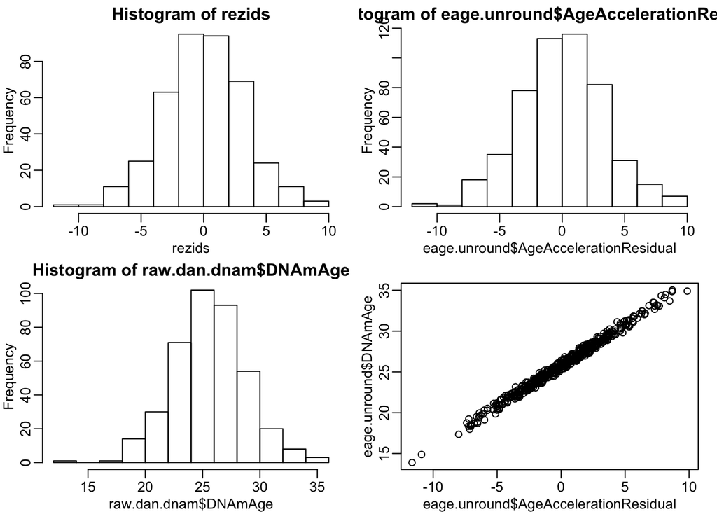

```r
# First, redo the DNAm2 using residuals of icage05_blood

age.rezids <-lm(DNAmAge~icage05_blood, raw.dan.dnam)

rezids <-residuals(age.rezids)

rafalib::mypar(2,2)
hist(rezids)
hist(eage.unround$AgeAccelerationResidual)
hist(raw.dan.dnam$DNAmAge)
plot(eage.unround$DNAmAge ~ eage.unround$AgeAccelerationResidual)
```

```r
mean(rezids)
```

```
## [1] -9.67447e-17
```

```r
sd(rezids)
```

```
## [1] 3.177594
```

```r
min(rezids)
```

```
## [1] -11.55159
```

```r
max(rezids)
```

```
## [1] 9.671291
```

The model…

```r
dnam6 <-lm(rezids~numbpreg + SES3 + icpc1 + icpc2 + icpc3 + icpc4 + icpc5 + icpc6 + icpc7 + icpc8 + icpc9 + icpc10  + urbanicity + currently_pregnant2, subset(raw.dan.dnam, !is.na(DNAmAge)))
summary(dnam6)
```

```
##
## Call:
## lm(formula = rezids ~ numbpreg + SES3 + icpc1 + icpc2 + icpc3 +
##     icpc4 + icpc5 + icpc6 + icpc7 + icpc8 + icpc9 + icpc10 +
##     urbanicity + currently_pregnant2, data = subset(raw.dan.dnam,
##     !is.na(DNAmAge)))
##
## Residuals:
##     Min      1Q  Median      3Q     Max
## -9.3727 -1.9309  0.0365  2.0724  8.8592
##
## Coefficients:
##                              Estimate Std. Error t value Pr(>|t|)
## (Intercept)                  -0.74974    0.52061  -1.440 0.150651
## numbpreg                      0.46145    0.16624   2.776 0.005779 **
## SES3                         -0.21199    0.12182  -1.740 0.082628 .
## icpc1                       -11.15452    6.58397  -1.694 0.091043 .
## icpc2                         4.75136    6.75768   0.703 0.482418
## icpc3                        10.10002    6.57287   1.537 0.125214
## icpc4                        10.41794    6.48485   1.607 0.108989
## icpc5                       -14.02222    6.08150  -2.306 0.021661 *
## icpc6                        -1.69233    6.58141  -0.257 0.797210
## icpc7                        21.25137    6.83834   3.108 0.002027 **
## icpc8                         3.94838    6.30807   0.626 0.531738
## icpc9                        -2.38552    6.35493  -0.375 0.707585
## icpc10                       -1.38041    6.65527  -0.207 0.835796
## urbanicity                    0.01645    0.01341   1.227 0.220660
## currently_pregnant2pregnant  -1.47222    0.43037  -3.421 0.000692 ***
## ---
## Signif. codes:  0 '***' 0.001 '**' 0.01 '*' 0.05 '.' 0.1 ' ' 1
##
## Residual standard error: 3.071 on 382 degrees of freedom
## Multiple R-squared:  0.09926,    Adjusted R-squared:  0.06625
## F-statistic: 3.007 on 14 and 382 DF,  p-value: 0.000209
```

The Plot…

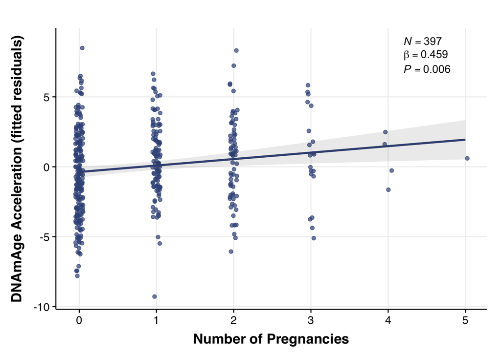

```r
# AV (partial R2 plot)
# https://stats.stackexchange.com/questions/125561/what-does-an-added-variable-plot-partial-regression-plot-explain-in-a-multiple

# Code from:
# https://stackoverflow.com/questions/43950459/use-ggplot-to-plot-partial-effects-obtained-with-effects-library

library(effects)

eff = effect("numbpreg", dnam6, partial.residuals=T)

library(gridExtra)

closest <- function(x, x0) apply(outer(x, x0, FUN=function(x, x0) abs(x - x0)), 1, which.min)

x.fit <- unlist(eff$x.all)
trans <- I
x <- data.frame(lower = eff$lower, upper = eff$upper, fit = eff$fit, numbpreg = eff$x$numbpreg)
xy <- data.frame(x = x.fit, y = x$fit[closest(trans(x.fit), x$numbpreg)] + eff$residuals)


obz <-nobs(dnam3)
beta <-round(broom::tidy(dnam3)[3,"estimate"], 3)
pval <-round(broom::tidy(dnam3)[3,"p.value"], 3)



g <- ggplot(x, aes(x = numbpreg, y = fit)) +
  theme_Publication() +
  geom_line(size = 1,col = "#3C5488FF") +
  geom_jitter(width = 0.05, data = xy, aes(x = x, y = y), alpha = 0.7, col = "#3C5488FF") +
  geom_ribbon(aes(ymin = lower, ymax = upper), alpha = 0.1, size = 1)+
  xlab("Number of Pregnancies")+
  ylab("DNAmAge Acceleration (fitted residuals)")+
  annotate("text", x=4.2, y=9, label = paste("italic(N)", "==", obz, sep = ""), parse=T, hjust = 0) +
  annotate("text", x=4.2, y=8, label = paste("beta", "==", beta, sep = ""), parse=T, hjust = 0) +
  annotate("text", x=4.2, y=7, label = paste("italic(P)", "==", pval, sep = ""), parse=T, hjust = 0);g
```

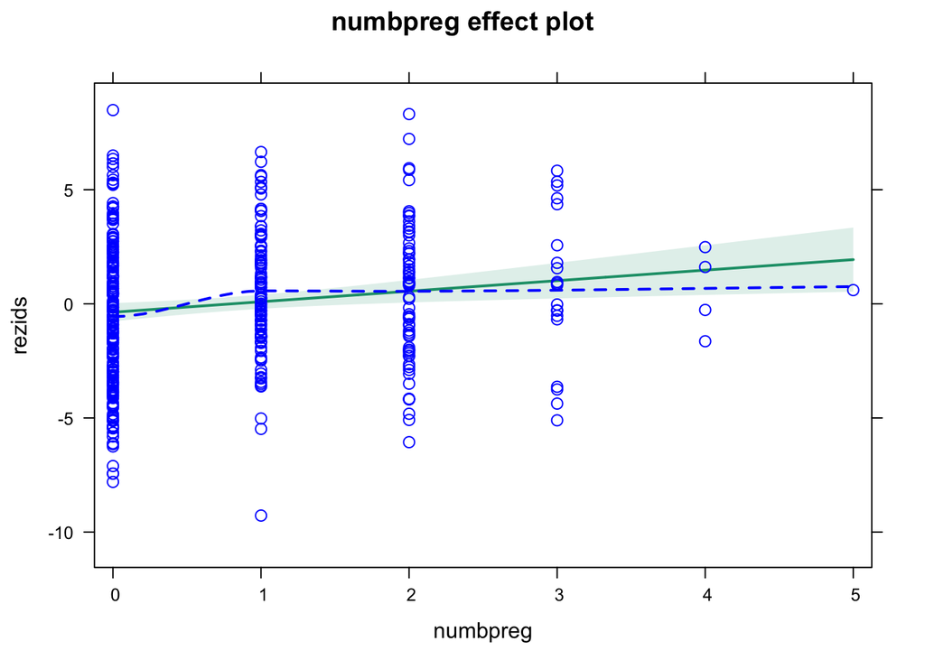

```r
#ggsave("DNAm_Preg.pdf", height = 5, width = 6)

# Check
plot(eff)
```

# 3 Telomere Models

Repeat with Telomere length Using “telomereICwell” variable

Setting up TL dataset - not shown *(reasons for separate data pull for TL embedded in code)*

```r
# I create a new dataframe because lm uses all datapoints. So the N keeps changing for the 3 models.

# Note that I had to remove the icpcfat.. values after pulling all with icpc

raw.dan.tl <-raw.dan %>%
  select(telomereICwell, icage05_blood, numbpreg, starts_with("icpc"), -contains('fat') , SES3, urbanicity, currently_pregnant2, momeducation) %>%
  na.omit()

dim(raw.dan.tl)
```

```
## [1] 821  17
```

```r
raw.dan.tl$currently_pregnant2 <-as.factor(raw.dan.tl$currently_pregnant2)
```

## 3.1 Summary of full data (from all including TL)

```r
foo.new <-raw.dan %>%
  select(icage05_blood, DNAmAge, numbpreg, momeducation, dadeducation, currently_pregnant2)

stargazer::stargazer(foo.new, nobs = T, mean.sd = T, min.max = T, type = 'latex')
```

% Table created by stargazer v.5.2 by Marek Hlavac, Harvard University. E-mail: hlavac at fas.harvard.edu % Date and time: Thu, Mar 08, 2018 - 19:06:27

# 4 Block to check for TL age in this pop, as Thom suggested.

```r
raw.dan %>%
  select(telomereICwell) %>%
  summary()
```

```
##  telomereICwell
##  Min.   :0.02905
##  1st Qu.:0.67396
##  Median :0.77588
##  Mean   :0.79286
##  3rd Qu.:0.89400
##  Max.   :1.44770
##  NA's   :1
```

```r
sd(raw.dan$telomereICwell, na.rm = T)
```

```
## [1] 0.1622391
```

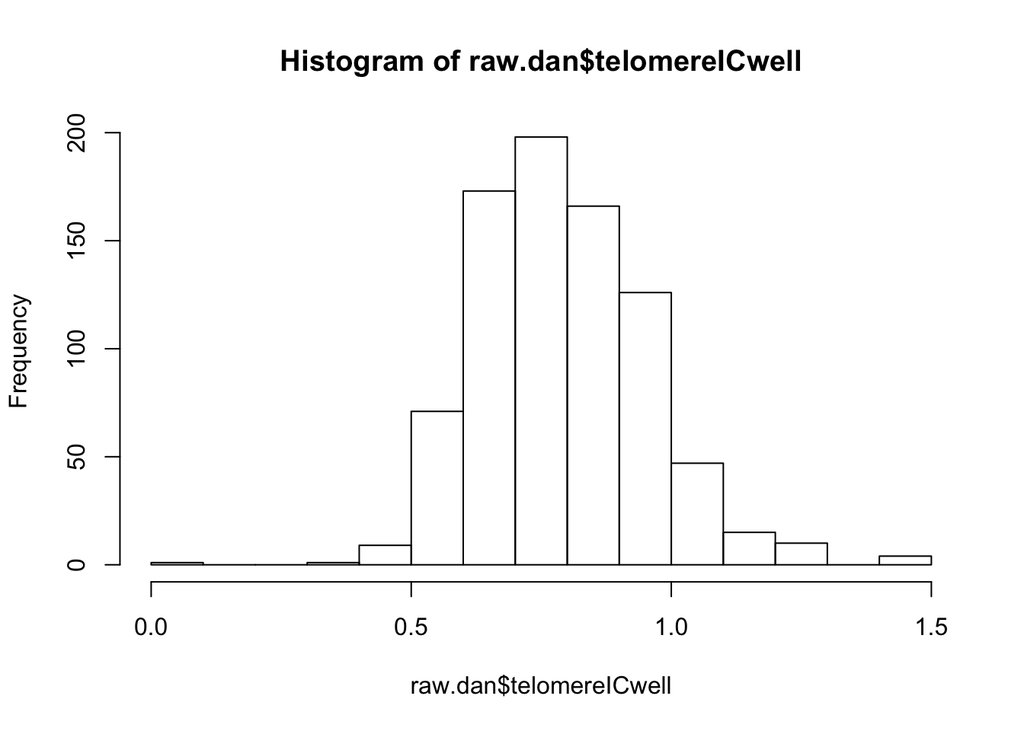

```r
hist(raw.dan$telomereICwell)
```

## 4.1 Telomere Model 1, number of observations and VIF

```r
tl1 <-lm(telomereICwell ~ icage05_blood + numbpreg, subset(raw.dan.tl,))
summary(tl1)
```

```
##
## Call:
## lm(formula = telomereICwell ~ icage05_blood + numbpreg, data = subset(raw.dan.tl,
##     ))
##
## Residuals:
##      Min       1Q   Median       3Q      Max
## -0.74662 -0.11079 -0.01431  0.09700  0.64107
##
## Coefficients:
##                Estimate Std. Error t value Pr(>|t|)
## (Intercept)    1.826471   0.342239   5.337 1.23e-07 ***
## icage05_blood -0.047269   0.015784  -2.995  0.00283 **
## numbpreg      -0.013636   0.006047  -2.255  0.02439 *
## ---
## Signif. codes:  0 '***' 0.001 '**' 0.01 '*' 0.05 '.' 0.1 ' ' 1
##
## Residual standard error: 0.161 on 818 degrees of freedom
## Multiple R-squared:  0.01765,    Adjusted R-squared:  0.01524
## F-statistic: 7.347 on 2 and 818 DF,  p-value: 0.000688
```

```r
raw.dan.tlX <-raw.dan.tl

raw.dan.tlX$Cat[raw.dan.tl$numbpreg == 0] <-0
raw.dan.tlX$Cat[raw.dan.tl$numbpreg == 1] <-1
raw.dan.tlX$Cat[raw.dan.tl$numbpreg == 2] <-2
raw.dan.tlX$Cat[raw.dan.tl$numbpreg >= 3] <-3

tl1b <-lm(telomereICwell ~ icage05_blood + Cat, subset(raw.dan.tlX,))
summary(tl1b)
```

```
##
## Call:
## lm(formula = telomereICwell ~ icage05_blood + Cat, data = subset(raw.dan.tlX,
##     ))
##
## Residuals:
##      Min       1Q   Median       3Q      Max
## -0.74662 -0.11232 -0.01441  0.09683  0.64102
##
## Coefficients:
##                Estimate Std. Error t value Pr(>|t|)
## (Intercept)    1.829420   0.342258   5.345 1.17e-07 ***
## icage05_blood -0.047402   0.015785  -3.003  0.00275 **
## Cat           -0.014122   0.006425  -2.198  0.02824 *
## ---
## Signif. codes:  0 '***' 0.001 '**' 0.01 '*' 0.05 '.' 0.1 ' ' 1
##
## Residual standard error: 0.161 on 818 degrees of freedom
## Multiple R-squared:  0.01734,    Adjusted R-squared:  0.01494
## F-statistic: 7.218 on 2 and 818 DF,  p-value: 0.000781
```

```r
# All models using Cat were <0.05
```

TL1 has N = 821

VIF not required - same covariates as dnam1

## 4.2 Telomere Model 2, number of observations and VIF

```r
tl2 <-lm(telomereICwell~icage05_blood + numbpreg+SES3 + icpc1 + icpc2 + icpc3 + icpc4 + icpc5 + icpc6 + icpc7 + icpc8 + icpc9 + icpc10 + urbanicity, subset(raw.dan.tl, ))
summary(tl2)
```

```
##
## Call:
## lm(formula = telomereICwell ~ icage05_blood + numbpreg + SES3 +
##     icpc1 + icpc2 + icpc3 + icpc4 + icpc5 + icpc6 + icpc7 + icpc8 +
##     icpc9 + icpc10 + urbanicity, data = subset(raw.dan.tl, ))
##
## Residuals:
##      Min       1Q   Median       3Q      Max
## -0.72638 -0.10618 -0.00540  0.09203  0.61168
##
## Coefficients:
##                 Estimate Std. Error t value Pr(>|t|)
## (Intercept)    1.3369826  0.3477879   3.844  0.00013 ***
## icage05_blood -0.0287100  0.0158489  -1.811  0.07044 .
## numbpreg      -0.0127730  0.0061625  -2.073  0.03852 *
## SES3          -0.0057638  0.0039226  -1.469  0.14212
## icpc1         -0.4192903  0.2265082  -1.851  0.06452 .
## icpc2         -0.1544323  0.2289168  -0.675  0.50011
## icpc3          0.0045836  0.2253894   0.020  0.98378
## icpc4         -0.0302654  0.2264555  -0.134  0.89371
## icpc5         -0.2348448  0.2317398  -1.013  0.31117
## icpc6         -0.2937503  0.2310566  -1.271  0.20398
## icpc7         -0.5060056  0.2339918  -2.162  0.03087 *
## icpc8          0.4208185  0.2286012   1.841  0.06601 .
## icpc9         -0.4623996  0.2242629  -2.062  0.03954 *
## icpc10         0.5546760  0.2382465   2.328  0.02015 *
## urbanicity     0.0024246  0.0004953   4.896 1.18e-06 ***
## ---
## Signif. codes:  0 '***' 0.001 '**' 0.01 '*' 0.05 '.' 0.1 ' ' 1
##
## Residual standard error: 0.1571 on 806 degrees of freedom
## Multiple R-squared:  0.07886,    Adjusted R-squared:  0.06286
## F-statistic: 4.929 on 14 and 806 DF,  p-value: 7.602e-09
```

TL2 has N = 821

VIF is the same as for DNAmAge data

## 4.3 Telomere Model 3, number of observations and VIF

```r
tl3 <-lm(telomereICwell~icage05_blood + numbpreg + SES3 + icpc1 + icpc2 + icpc3 + icpc4 + icpc5 + icpc6 + icpc7 + icpc8 + icpc9 + icpc10 +  urbanicity + currently_pregnant2, subset(raw.dan.tl,))
summary(tl3);nobs(tl3)
```

```
##
## Call:
## lm(formula = telomereICwell ~ icage05_blood + numbpreg + SES3 +
##     icpc1 + icpc2 + icpc3 + icpc4 + icpc5 + icpc6 + icpc7 + icpc8 +
##     icpc9 + icpc10 + urbanicity + currently_pregnant2, data = subset(raw.dan.tl,
##     ))
##
## Residuals:
##      Min       1Q   Median       3Q      Max
## -0.72655 -0.10579 -0.00444  0.09327  0.61373
##
## Coefficients:
##                               Estimate Std. Error t value Pr(>|t|)
## (Intercept)                  1.3315970  0.3480278   3.826  0.00014 ***
## icage05_blood               -0.0284755  0.0158594  -1.795  0.07295 .
## numbpreg                    -0.0137803  0.0063737  -2.162  0.03091 *
## SES3                        -0.0055367  0.0039410  -1.405  0.16044
## icpc1                       -0.4176814  0.2266091  -1.843  0.06567 .
## icpc2                       -0.1550579  0.2290060  -0.677  0.49854
## icpc3                        0.0012985  0.2255369   0.006  0.99541
## icpc4                       -0.0261325  0.2266389  -0.115  0.90823
## icpc5                       -0.2368688  0.2318507  -1.022  0.30726
## icpc6                       -0.3008525  0.2314261  -1.300  0.19398
## icpc7                       -0.5153544  0.2345623  -2.197  0.02830 *
## icpc8                        0.4206067  0.2286883   1.839  0.06625 .
## icpc9                       -0.4595275  0.2243956  -2.048  0.04090 *
## icpc10                       0.5506015  0.2384270   2.309  0.02118 *
## urbanicity                   0.0024132  0.0004958   4.867 1.36e-06 ***
## currently_pregnant2pregnant  0.0109666  0.0176213   0.622  0.53389
## ---
## Signif. codes:  0 '***' 0.001 '**' 0.01 '*' 0.05 '.' 0.1 ' ' 1
##
## Residual standard error: 0.1571 on 805 degrees of freedom
## Multiple R-squared:  0.0793, Adjusted R-squared:  0.06215
## F-statistic: 4.623 on 15 and 805 DF,  p-value: 1.492e-08
```

```
## [1] 821
```

TL2 has N = 821

VIF not required - same covariates as dnam2

## 4.4 Telomere Model 4, number of observations and VIF

```r
tl4 <-lm(telomereICwell~icage05_blood + numbpreg*SES3 + icpc1 + icpc2 + icpc3 + icpc4 + icpc5 + icpc6 + icpc7 + icpc8 + icpc9 + icpc10 + urbanicity + currently_pregnant2, subset(raw.dan.tl, ))
summary(tl4)
```

```
##
## Call:
## lm(formula = telomereICwell ~ icage05_blood + numbpreg * SES3 +
##     icpc1 + icpc2 + icpc3 + icpc4 + icpc5 + icpc6 + icpc7 + icpc8 +
##     icpc9 + icpc10 + urbanicity + currently_pregnant2, data = subset(raw.dan.tl,
##     ))
##
## Residuals:
##      Min       1Q   Median       3Q      Max
## -0.73201 -0.10726 -0.00408  0.09267  0.61652
##
## Coefficients:
##                               Estimate Std. Error t value Pr(>|t|)
## (Intercept)                  1.3430729  0.3482903   3.856 0.000124 ***
## icage05_blood               -0.0290594  0.0158739  -1.831 0.067525 .
## numbpreg                    -0.0163577  0.0069710  -2.347 0.019191 *
## SES3                        -0.0037485  0.0044009  -0.852 0.394607
## icpc1                       -0.4187729  0.2266356  -1.848 0.065001 .
## icpc2                       -0.1425844  0.2294364  -0.621 0.534477
## icpc3                        0.0072015  0.2256527   0.032 0.974548
## icpc4                       -0.0334585  0.2268041  -0.148 0.882757
## icpc5                       -0.2307331  0.2319719  -0.995 0.320201
## icpc6                       -0.2906310  0.2317203  -1.254 0.210122
## icpc7                       -0.5167757  0.2345916  -2.203 0.027887 *
## icpc8                        0.4254141  0.2287724   1.860 0.063314 .
## icpc9                       -0.4649235  0.2244964  -2.071 0.038681 *
## icpc10                       0.5439216  0.2385637   2.280 0.022870 *
## urbanicity                   0.0024483  0.0004973   4.923 1.03e-06 ***
## currently_pregnant2pregnant  0.0108306  0.0176238   0.615 0.539031
## numbpreg:SES3               -0.0039073  0.0042778  -0.913 0.361310
## ---
## Signif. codes:  0 '***' 0.001 '**' 0.01 '*' 0.05 '.' 0.1 ' ' 1
##
## Residual standard error: 0.1571 on 804 degrees of freedom
## Multiple R-squared:  0.08026,    Adjusted R-squared:  0.06196
## F-statistic: 4.385 on 16 and 804 DF,  p-value: 2.372e-08
```

TL3 has N = 821

VIF not required - same covariates as dnam3

Multicollinearity not a problem (same models)

## 4.5 Plot of Telomere Model 3 (partial regression controlling for others)

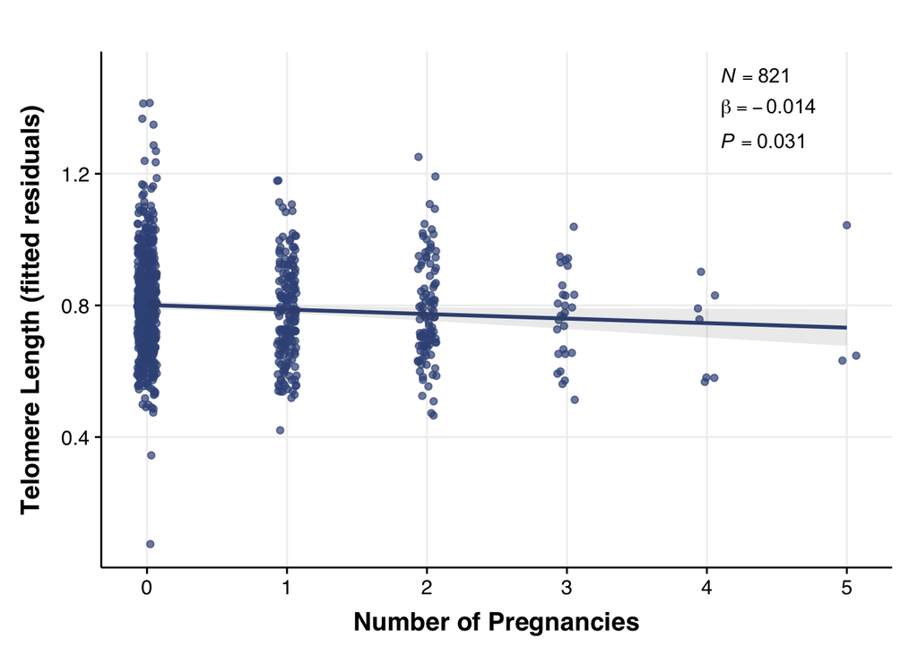

```r
eff = effect("numbpreg", tl3, partial.residuals=T)

closest <- function(x, x0) apply(outer(x, x0, FUN=function(x, x0) abs(x - x0)), 1, which.min)

x.fit <- unlist(eff$x.all)
trans <- I
x <- data.frame(lower = eff$lower, upper = eff$upper, fit = eff$fit, numbpreg = eff$x$numbpreg)
xy <- data.frame(x = x.fit, y = x$fit[closest(trans(x.fit), x$numbpreg)] + eff$residuals)



obz <-nobs(tl3)
beta <-round(broom::tidy(tl3)[3,"estimate"], 3)
pval <-round(broom::tidy(tl3)[3,"p.value"], 3)




g <- ggplot(x, aes(x = numbpreg, y = fit)) +
  theme_Publication() +
  geom_line(size = 1,col = "#3C5488FF") +
  geom_jitter(width = 0.07, data = xy, aes(x = x, y = y), alpha = 0.7, col = "#3C5488FF") +
  geom_ribbon(aes(ymin = lower, ymax = upper), alpha = 0.1, size = 1)+
  xlab("Number of Pregnancies")+
  ylab("Telomere Length (fitted residuals)")+
  annotate("text", x=4.1, y=1.5, label = paste("italic(N)", "==", obz, sep = ""), parse=T, hjust = 0) +
  annotate("text", x=4.1, y=1.4, label = paste("beta", "==", beta, sep = ""), parse=T, hjust = 0) +
  annotate("text", x=4.1, y=1.3, label = paste("italic(P)", "==", pval, sep = ""), parse=T, hjust = 0);g
```

```r
# ggsave("TL_Preg.pdf", height = 5, width = 6)
```

# 5 DNAm and TL

## 5.1 models summary table (reduced)

```r
stargazer::stargazer(tl1, tl2, tl3, tl4, dnam1, dnam2, dnam3, dnam4, dep.var.labels = c("<b> Telomere Length~</b>", "<b>DNAmAge~</b>"), single.row = F, align = T, intercept.bottom = T, no.space = T, dep.var.caption = "", type = "html", out = "CoR_models_reduced.html", report = "vc*",  omit = c("icpc1","icpc2","icpc3","icpc4","icpc5","icpc6","icpc7","icpc8","icpc9","icpc10", "urbanicity"), omit.stat = c("rsq", "f", "ser"), star.char = c("+", "*", "**", "***"), digits = 3, order = c(1, 2, 3, 15, 16), notes = "+p<0.1;*p<0.05;**p<0.01;***p<0.001 ", notes.append = FALSE, covariate.labels = c("Age","No.Pregnancies","SES", "Currently Pregnant (Y)", "No.Pregnancies x SES", "Intercept"))
```

|  | **Telomere Length~** |  |  |  | **DNAmAge~** |  |  |  |
| --- | --- | --- | --- | --- | --- | --- | --- | --- |
|  | (1) | (2) | (3) | (4) | (5) | (6) | (7) | (8) |
| Age | -0.047** | -0.029<sup>+</sup> | -0.028<sup>+</sup> | -0.029<sup>+</sup> | 0.485 | 0.667 | 0.656 | 0.645 |
| No.Pregnancies | -0.014* | -0.013* | -0.014* | -0.016* | 0.363* | 0.326* | 0.459** | 0.510** |
| SES |  | -0.006 | -0.006 | -0.004 |  | -0.180 | -0.214<sup>+</sup> | -0.291<sup>+</sup> |
| Currently Pregnant (Y) |  |  | 0.011 | 0.011 |  |  | -1.472** | -1.460** |
| No.Pregnancies x SES |  |  |  | -0.004 |  |  |  | 0.106 |
| Intercept | 1.826** | 1.337** | 1.332** | 1.343** | 14.818 | 10.319 | 10.611 | 10.850 |
| Observations | 821 | 821 | 821 | 821 | 397 | 397 | 397 | 397 |
| Adjusted R<sup>2</sup> | 0.015 | 0.063 | 0.062 | 0.062 | 0.011 | 0.041 | 0.067 | 0.067 |
| *Note:* | +p<0.1;*p<0.05;**p<0.01;***p<0.001 |  |  |  |  |  |  |  |

## 5.2 models summary table (full)

```r
stargazer::stargazer(tl1, tl2, tl3, tl4, dnam1, dnam2, dnam3, dnam4, dep.var.labels = c("<b> Telomere Length~</b>", "<b>DNAmAge~</b>"), single.row = F, align = T, intercept.bottom = T, no.space = T, dep.var.caption = "", type = "html", out = "CoR_models.html", star.char = c("+", "*", "**", "***"), digits = 3, report = "vcp*", order = c(1,2,4:13,3,14,15,16,17,18), notes = "+p<0.1;*p<0.05;**p<0.01;***p<0.001 ", notes.append = FALSE, covariate.labels = c("Age",
                                          "No.Pregnancies",
                                          "PC1",
                                          "PC2",
                                          "PC3",
                                          "PC4",
                                          "PC5",
                                          "PC6",
                                          "PC7",
                                          "PC8",
                                          "PC9",
                                          "PC10",
                                          "SES-score",
                                          "Urbanicity-score",
                                          "Currently Pregnancy (Y)",
                                          "No.Pregnancies*SES-score",
                                          "Intercept"))
```

|  | **Telomere Length~** |  |  |  | **DNAmAge~** |  |  |  |
| --- | --- | --- | --- | --- | --- | --- | --- | --- |
|  | (1) | (2) | (3) | (4) | (5) | (6) | (7) | (8) |
| Age | -0.047 | -0.029 | -0.028 | -0.029 | 0.485 | 0.667 | 0.656 | 0.645 |
|  | p = 0.003** | p = 0.071<sup>+</sup> | p = 0.073<sup>+</sup> | p = 0.068<sup>+</sup> | p = 0.293 | p = 0.157 | p = 0.158 | p = 0.165 |
| No.Pregnancies | -0.014 | -0.013 | -0.014 | -0.016 | 0.363 | 0.326 | 0.459 | 0.510 |
|  | p = 0.025* | p = 0.039* | p = 0.031* | p = 0.020* | p = 0.026* | p = 0.049* | p = 0.007** | p = 0.005** |
| PC1 |  | -0.419 | -0.418 | -0.419 |  | -11.623 | -11.250 | -11.219 |
|  |  | p = 0.065<sup>+</sup> | p = 0.066<sup>+</sup> | p = 0.066<sup>+</sup> |  | p = 0.084<sup>+</sup> | p = 0.090<sup>+</sup> | p = 0.091<sup>+</sup> |
| PC2 |  | -0.154 | -0.155 | -0.143 |  | 5.098 | 4.793 | 4.341 |
|  |  | p = 0.501 | p = 0.499 | p = 0.535 |  | p = 0.458 | p = 0.480 | p = 0.523 |
| PC3 |  | 0.005 | 0.001 | 0.007 |  | 8.510 | 10.074 | 9.856 |
|  |  | p = 0.984 | p = 0.996 | p = 0.975 |  | p = 0.202 | p = 0.127 | p = 0.136 |
| PC4 |  | -0.030 | -0.026 | -0.033 |  | 11.991 | 10.450 | 10.511 |
|  |  | p = 0.894 | p = 0.909 | p = 0.883 |  | p = 0.069<sup>+</sup> | p = 0.109 | p = 0.107 |
| PC5 |  | -0.235 | -0.237 | -0.231 |  | -14.123 | -14.033 | -13.766 |
|  |  | p = 0.312 | p = 0.308 | p = 0.321 |  | p = 0.023* | p = 0.022* | p = 0.025* |
| PC6 |  | -0.294 | -0.301 | -0.291 |  | -4.002 | -1.683 | -2.286 |
|  |  | p = 0.204 | p = 0.194 | p = 0.211 |  | p = 0.548 | p = 0.799 | p = 0.731 |
| PC7 |  | -0.506 | -0.515 | -0.517 |  | 18.513 | 21.220 | 21.471 |
|  |  | p = 0.031* | p = 0.029* | p = 0.028* |  | p = 0.008** | p = 0.003** | p = 0.002** |
| PC8 |  | 0.421 | 0.421 | 0.425 |  | 3.987 | 3.930 | 3.829 |
|  |  | p = 0.067<sup>+</sup> | p = 0.067<sup>+</sup> | p = 0.064<sup>+</sup> |  | p = 0.534 | p = 0.535 | p = 0.545 |
| PC9 |  | -0.462 | -0.460 | -0.465 |  | -1.730 | -2.332 | -2.337 |
|  |  | p = 0.040* | p = 0.041* | p = 0.039* |  | p = 0.789 | p = 0.715 | p = 0.714 |
| PC10 |  | 0.555 | 0.551 | 0.544 |  | -2.701 | -1.329 | -1.043 |
|  |  | p = 0.021* | p = 0.022* | p = 0.023* |  | p = 0.690 | p = 0.843 | p = 0.876 |
| SES-score |  | -0.006 | -0.006 | -0.004 |  | -0.180 | -0.214 | -0.291 |
|  |  | p = 0.143 | p = 0.161 | p = 0.395 |  | p = 0.146 | p = 0.081<sup>+</sup> | p = 0.055<sup>+</sup> |
| Urbanicity-score |  | 0.002 | 0.002 | 0.002 |  | 0.015 | 0.017 | 0.017 |
|  |  | p = 0.00001** | p = 0.00001** | p = 0.00001** |  | p = 0.270 | p = 0.213 | p = 0.226 |
| Currently Pregnancy (Y) |  |  | 0.011 | 0.011 |  |  | -1.472 | -1.460 |
|  |  |  | p = 0.534 | p = 0.540 |  |  | p = 0.001** | p = 0.001** |
| No.Pregnancies*SES-score |  |  |  | -0.004 |  |  |  | 0.106 |
|  |  |  |  | p = 0.362 |  |  |  | p = 0.385 |
| Intercept | 1.826 | 1.337 | 1.332 | 1.343 | 14.818 | 10.319 | 10.611 | 10.850 |
|  | p = 0.00000** | p = 0.0002** | p = 0.0002** | p = 0.0002** | p = 0.138 | p = 0.318 | p = 0.297 | p = 0.287 |
| Observations | 821 | 821 | 821 | 821 | 397 | 397 | 397 | 397 |
| R<sup>2</sup> | 0.018 | 0.079 | 0.079 | 0.080 | 0.016 | 0.075 | 0.103 | 0.104 |
| Adjusted R<sup>2</sup> | 0.015 | 0.063 | 0.062 | 0.062 | 0.011 | 0.041 | 0.067 | 0.067 |
| Residual Std. Error | 0.161 (df = 818) | 0.157 (df = 806) | 0.157 (df = 805) | 0.157 (df = 804) | 3.165 (df = 394) | 3.117 (df = 382) | 3.074 (df = 381) | 3.075 (df = 380) |
| F Statistic | 7.347** (df = 2; 818) | 4.929** (df = 14; 806) | 4.623** (df = 15; 805) | 4.385** (df = 16; 804) | 3.220* (df = 2; 394) | 2.214** (df = 14; 382) | 2.902** (df = 15; 381) | 2.766** (df = 16; 380) |
| *Note:* | +p<0.1;*p<0.05;**p<0.01;***p<0.001 |  |  |  |  |  |  |  |

## 5.3 Correlation bt. DNAm and TL (age not factored out)

```r
dnam.tl <-lm(telomereICwell~DNAmAge, data = raw.dan)
summary(dnam.tl)
```

```
##
## Call:
## lm(formula = telomereICwell ~ DNAmAge, data = raw.dan)
##
## Residuals:
##      Min       1Q   Median       3Q      Max
## -0.32816 -0.10801 -0.02285  0.09576  0.62031
##
## Coefficients:
##              Estimate Std. Error t value Pr(>|t|)
## (Intercept)  0.813799   0.062266  13.070   <2e-16 ***
## DNAmAge     -0.001106   0.002412  -0.458    0.647
## ---
## Signif. codes:  0 '***' 0.001 '**' 0.01 '*' 0.05 '.' 0.1 ' ' 1
##
## Residual standard error: 0.1528 on 394 degrees of freedom
##   (426 observations deleted due to missingness)
## Multiple R-squared:  0.0005331,  Adjusted R-squared:  -0.002004
## F-statistic: 0.2102 on 1 and 394 DF,  p-value: 0.6469
```

```r
nobs(dnam.tl)
```

```
## [1] 396
```

# 6 Parity Analyses

**NB** - *this is using the ‘incorrect’ epigenetic age data (calculated with icage05, not icage05_blood). Any age accel values will reflect this. Simple measures such as DNAmAge will not.* **To get around this problem I have calculated a new measure of AgeAccel (.blood)**

## 6.1 Load Parity Data (not shown)

```r
parity <- read_dta("~/Academic/PhD/Projects/eAge/eAge_effects/Pre_Pub_analyses/05to09parity.dta")
```

## 6.2 Setup Parity Data. Create new AgeAccel measure using icage05_blood. Compare ages.

Because: DNAmAge ~ Age = DNAmAgeAdjAge

Then… DNAmAge ~ icage05_blood = DNAmAgeAdjAge

**NB**: These may be a bit off (R^2 != 1) because resids for DNAmAdjAge can be calculated for all individuals (males and females) but in my analyses, it’s a subset of females only.

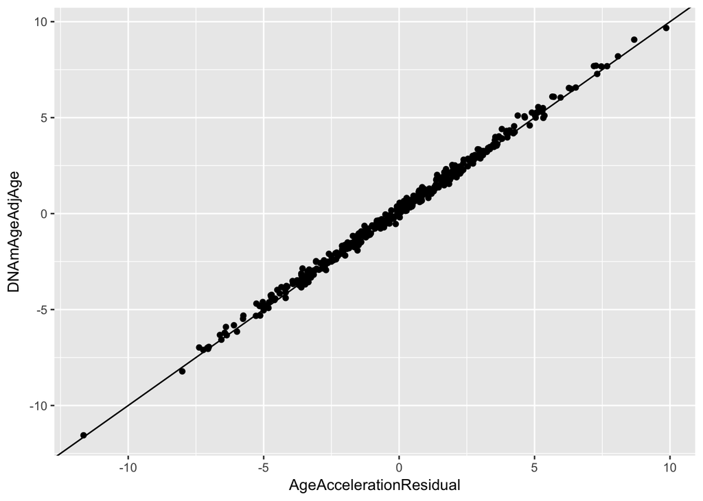

```r
# Merge parity + raw.dan:
parity$uncchdid <-as.character(parity$uncchdid)

parity.big <-left_join(raw.dan, parity, by = "uncchdid")

# Make BioAge1H0AdjAge.blood
# DNAmAge ~ icage05_blood = DNAmAgeAdjAge

foo.age <-lm(parity.big$DNAmAge ~ parity.big$icage05_blood, na.action = na.exclude)

parity.big$DNAmAgeAdjAge <- residuals(foo.age)

ggplot(parity.big, aes(AgeAccelerationResidual, DNAmAgeAdjAge)) +
  geom_point()+
  geom_abline()
```

```r
# Ok, small difference, but worth doing.
```

## 6.3 DNAmAge predicting parity…

```r
# glm poisson, quasipoisson, or negbinomial
# Outcome = repro05to09
# Predictors = days05to09 + parity05 + BioAge1H0AdjAge.blood

parity.big$parity05 <-as.integer(parity.big$parity05)
parity.big$repro05to09 <-as.integer(parity.big$repro05to09)


pois <-glm(repro05to09 ~ days05to09 + parity05 + DNAmAgeAdjAge, family = "poisson", data = parity.big); summary(pois)
```

```
##
## Call:
## glm(formula = repro05to09 ~ days05to09 + parity05 + DNAmAgeAdjAge,
##     family = "poisson", data = parity.big)
##
## Deviance Residuals:
##      Min        1Q    Median        3Q       Max
## -1.66186  -1.27846   0.01614   0.34815   2.98723
##
## Coefficients:
##                Estimate Std. Error z value Pr(>|z|)
## (Intercept)    3.267199   1.876985   1.741   0.0817 .
## days05to09    -0.002339   0.001280  -1.827   0.0677 .
## parity05       0.123355   0.050725   2.432   0.0150 *
## DNAmAgeAdjAge -0.016139   0.016396  -0.984   0.3250
## ---
## Signif. codes:  0 '***' 0.001 '**' 0.01 '*' 0.05 '.' 0.1 ' ' 1
##
## (Dispersion parameter for poisson family taken to be 1)
##
##     Null deviance: 392.12  on 396  degrees of freedom
## Residual deviance: 382.28  on 393  degrees of freedom
##   (425 observations deleted due to missingness)
## AIC: 972.87
##
## Number of Fisher Scoring iterations: 5
```

```r
# Check the overdispersion using the following info:
# https://stats.stackexchange.com/questions/66586/is-there-a-test-to-determine-whether-glm-overdispersion-is-significant
# library(AER)

dispersiontest(pois)
```

```
##
##  Overdispersion test
##
## data:  pois
## z = -3.2767, p-value = 0.9995
## alternative hypothesis: true dispersion is greater than 1
## sample estimates:
## dispersion
##  0.7932966
```

```r
# Poisson model does not appear to be overdispersed. (P < 0.05 suggest overdispersion)

### JUst in Case, reran using quasi and nb and no evidence for DNAmAge predicting reproduction between 05 and 09

# qpois <-glm(repro05to09 ~ days05to09 + parity05 + DNAmAgeAdjAge.blood, family = "quasipoisson", data = parity.big); summary(qpois)
#
# # library(MASS)
#
# nb <-glm.nb(repro05to09 ~ days05to09 + parity05 + DNAmAgeAdjAge.blood, data = parity.big); summary(nb)

pois.min <-glm(repro05to09 ~ days05to09 + DNAmAgeAdjAge, family = "poisson", data = parity.big); summary(pois.min)
```

```
##
## Call:
## glm(formula = repro05to09 ~ days05to09 + DNAmAgeAdjAge, family = "poisson",
##     data = parity.big)
##
## Deviance Residuals:
##      Min        1Q    Median        3Q       Max
## -1.55564  -1.31221   0.02843   0.24611   2.99052
##
## Coefficients:
##                Estimate Std. Error z value Pr(>|z|)
## (Intercept)    3.461482   1.853245   1.868   0.0618 .
## days05to09    -0.002400   0.001265  -1.897   0.0578 .
## DNAmAgeAdjAge -0.011336   0.016168  -0.701   0.4832
## ---
## Signif. codes:  0 '***' 0.001 '**' 0.01 '*' 0.05 '.' 0.1 ' ' 1
##
## (Dispersion parameter for poisson family taken to be 1)
##
##     Null deviance: 392.12  on 396  degrees of freedom
## Residual deviance: 387.97  on 394  degrees of freedom
##   (425 observations deleted due to missingness)
## AIC: 976.55
##
## Number of Fisher Scoring iterations: 5
```

> Summary: Poisson GLM does not show signs that DNAmAge in 05 predicts parity between 05 and 09, accounting for the time between measurement and parity in 05. Poisson model does not show signs of overdispersion. Negative binomial shows the same outcome essentially.

## 6.4 TELOMERE length predicting parity…

```r
pois.tl <-glm(repro05to09 ~ days05to09 + parity05 + telomereICwell, family = "poisson", data = parity.big); summary(pois.tl)
```

```
##
## Call:
## glm(formula = repro05to09 ~ days05to09 + parity05 + telomereICwell,
##     family = "poisson", data = parity.big)
##
## Deviance Residuals:
##     Min       1Q   Median       3Q      Max
## -2.1308  -1.1124  -0.2722   0.4845   3.1571
##
## Coefficients:
##                 Estimate Std. Error z value Pr(>|z|)
## (Intercept)     3.719119   1.649168   2.255   0.0241 *
## days05to09     -0.002959   0.001153  -2.567   0.0103 *
## parity05        0.252025   0.039411   6.395 1.61e-10 ***
## telomereICwell  0.154840   0.285737   0.542   0.5879
## ---
## Signif. codes:  0 '***' 0.001 '**' 0.01 '*' 0.05 '.' 0.1 ' ' 1
##
## (Dispersion parameter for poisson family taken to be 1)
##
##     Null deviance: 825.43  on 737  degrees of freedom
## Residual deviance: 780.58  on 734  degrees of freedom
##   (84 observations deleted due to missingness)
## AIC: 1636.7
##
## Number of Fisher Scoring iterations: 5
```

```r
dispersiontest(pois.tl)
```

```
##
##  Overdispersion test
##
## data:  pois.tl
## z = -0.61237, p-value = 0.7299
## alternative hypothesis: true dispersion is greater than 1
## sample estimates:
## dispersion
##  0.9710754
```

```r
# NO evidence for overdispersion of the TL model. (P < 0.05 suggest over/under dispersion)

# Just in case, check quasi and NB. No evidence again.
#
# qpois.tl <-glm(repro05to09 ~ days05to09 + parity05 + TL_age_residual, family = "quasipoisson", data = parity.big); summary(qpois.tl)
#
#
# nb.TL <-glm.nb(repro05to09 ~ days05to09 + parity05 + TL_age_residual, data = parity.big); summary(nb.TL)

pois.tl.min <-glm(repro05to09 ~ days05to09  + telomereICwell, family = "poisson", data = parity.big); summary(pois.tl.min)
```

```
##
## Call:
## glm(formula = repro05to09 ~ days05to09 + telomereICwell, family = "poisson",
##     data = parity.big)
##
## Deviance Residuals:
##     Min       1Q   Median       3Q      Max
## -1.4330  -1.1879   0.0767   0.3862   3.2679
##
## Coefficients:
##                 Estimate Std. Error z value Pr(>|z|)
## (Intercept)     4.313458   1.614004   2.673  0.00753 **
## days05to09     -0.003174   0.001131  -2.807  0.00499 **
## telomereICwell  0.041097   0.283658   0.145  0.88480
## ---
## Signif. codes:  0 '***' 0.001 '**' 0.01 '*' 0.05 '.' 0.1 ' ' 1
##
## (Dispersion parameter for poisson family taken to be 1)
##
##     Null deviance: 825.43  on 737  degrees of freedom
## Residual deviance: 817.32  on 735  degrees of freedom
##   (84 observations deleted due to missingness)
## AIC: 1671.5
##
## Number of Fisher Scoring iterations: 5
```

> Summary: Poisson GLM does not show signs that TL in 05 predicts parity between 05 and 09, accounting for the time between measurement and parity in 05. Poisson model does not show signs of overdispersion. Negative binomial shows the same outcome essentially.

### 6.4.1 Table of models of TL/DNAmAge predicting parity 05-09:

```r
stargazer::stargazer(pois.tl.min, pois.tl, pois.min, pois, dep.var.labels = c("<b>Parity 2005-2009</b>"),
                     column.labels = c("<b>Age Adjusted TL~</b>"," ","<b>Age Adjusted DNAmAge</b>~"),
                     single.row = F, align = T, intercept.bottom = T, no.space = T,
                     star.char = c("+", "*", "**", "***"), digits = 3, report = "vcp*",
                     notes = "+p<0.1;*p<0.05;**p<0.01;***p<0.001 ", notes.append = FALSE,
                     covariate.labels = c("Measurement time bt. 2005-2009 (Days)",
                                          "Parity in 2005",
                                          "Age Adjusted Telomere Length in 2005",
                                          "Age Adjusted DNAmAge in 2005",
                                          "Intercept"),
                     type = "html",
                     out = "parity_pois.html",
                     dep.var.caption = "")
```

|  | **Parity 2005-2009** |  |  |  |
| --- | --- | --- | --- | --- |
|  | **Age Adjusted TL~** |  | **Age Adjusted DNAmAge**~ |  |
|  | (1) | (2) | (3) | (4) |
| Measurement time bt. 2005-2009 (Days) | -0.003 | -0.003 | -0.002 | -0.002 |
|  | p = 0.005** | p = 0.011* | p = 0.058<sup>+</sup> | p = 0.068<sup>+</sup> |
| Parity in 2005 |  | 0.252 |  | 0.123 |
|  |  | p = 0.000** |  | p = 0.016* |
| Age Adjusted Telomere Length in 2005 | 0.041 | 0.155 |  |  |
|  | p = 0.885 | p = 0.588 |  |  |
| Age Adjusted DNAmAge in 2005 |  |  | -0.011 | -0.016 |
|  |  |  | p = 0.484 | p = 0.325 |
| Intercept | 4.313 | 3.719 | 3.461 | 3.267 |
|  | p = 0.008** | p = 0.025* | p = 0.062<sup>+</sup> | p = 0.082<sup>+</sup> |
| Observations | 738 | 738 | 397 | 397 |
| Log Likelihood | -832.737 | -814.371 | -485.277 | -482.434 |
| Akaike Inf. Crit. | 1,671.474 | 1,636.742 | 976.553 | 972.867 |
| *Note:* | +p<0.1;*p<0.05;**p<0.01;***p<0.001 |  |  |  |

```r
# broom::tidy(pois)
#
# broom::tidy(pois.tl)
```

```r
pois.data <-parity.big %>%
  select(repro05to09, days05to09, parity05, DNAmAgeAdjAge) %>%
  na.omit()
```

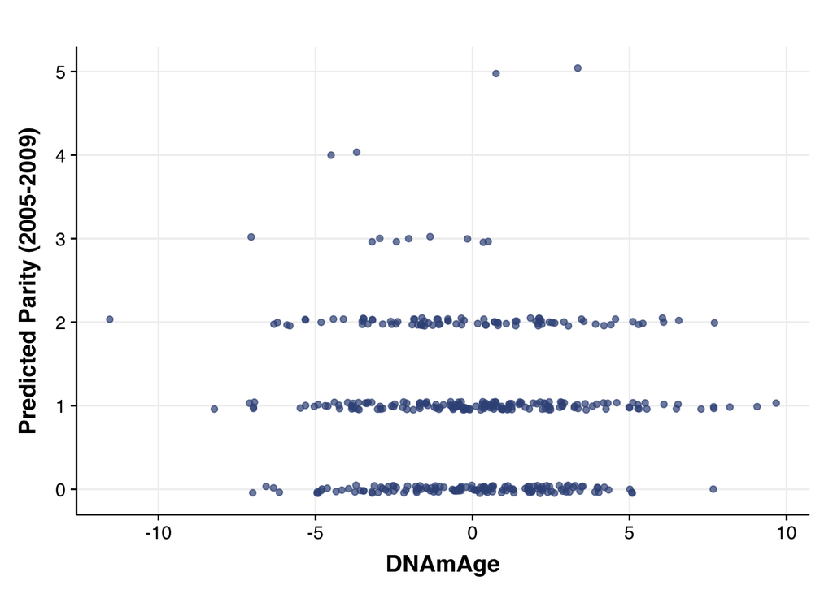

```r
#  pois_smooth <- function(...) {
#   geom_smooth(method = "glm", method.args = list(family = "poisson"), ...)
# }

g <- ggplot(pois.data, aes(x = DNAmAgeAdjAge, y = repro05to09)) +
  theme_Publication() +
  #geom_smooth(size = 1,col = "#3C5488FF") +
  geom_jitter(height = 0.05, alpha = 0.7, col = "#3C5488FF")+
  xlab("DNAmAge")+
  ylab("Predicted Parity (2005-2009)");g
```

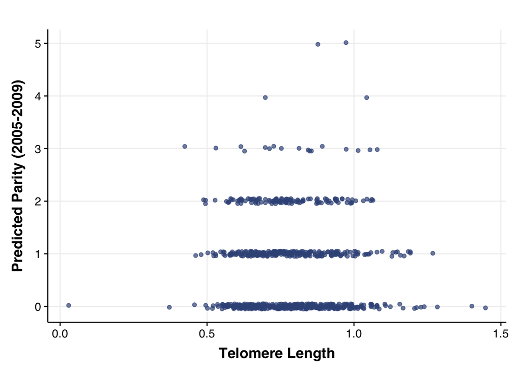

```r
h <- ggplot(parity.big, aes(x = telomereICwell, y = repro05to09)) +
  theme_Publication() +
  #geom_smooth(size = 1,col = "#3C5488FF") +
  geom_jitter(height = 0.05, alpha = 0.7, col = "#3C5488FF")+
  xlab("Telomere Length")+
  ylab("Predicted Parity (2005-2009)");h
```

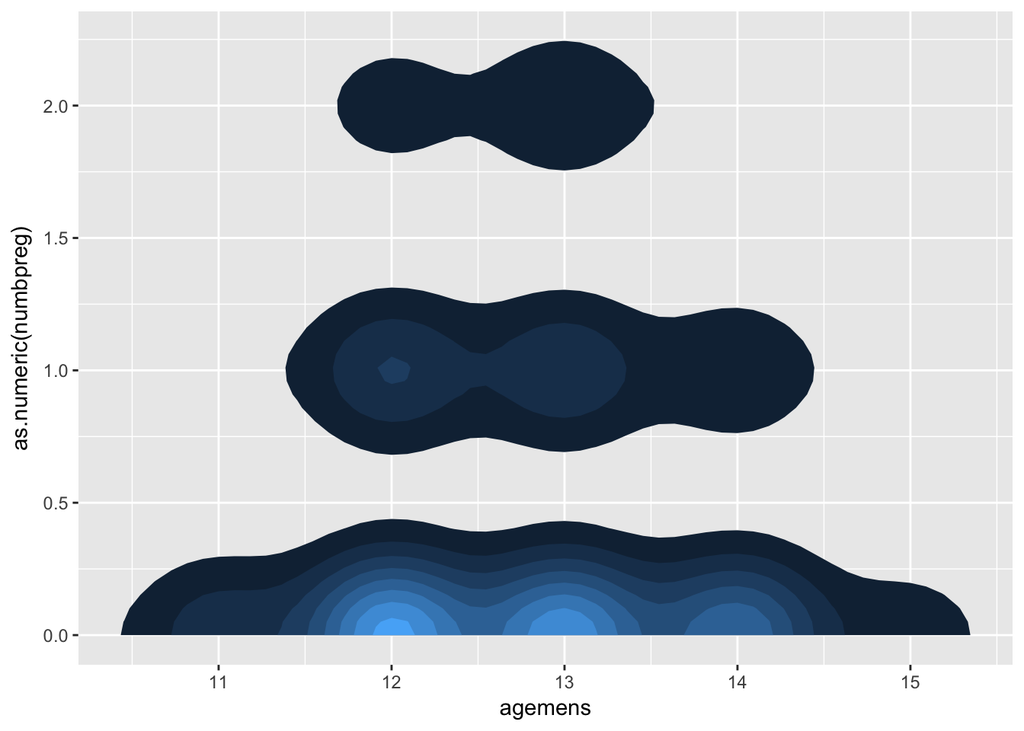

```r
p1 <- ggplot(raw.dan,aes(x=agemens,y=as.numeric(numbpreg)))+
  stat_density2d(aes(fill=..level..), geom="polygon") +
  theme(legend.position = "none");p1
```